# Сумма Минковского

# Содержание

- Что такое сумма Минковского
- Сумма двух выпуклых фигур
- Сумма двух невыпуклых фигур

Случай суммы выпуклой и невыпуклой фигуры будет рассмотрен в отдельном билете(#13).

Сначала будет много теории, чтобы понять с чем мы вообще работаем, а потом разберемся как это реализовать на практике.

## Что такое сумма Минковского

### Сумма Минковского

Множество $C$ является суммой Минковского множеств $A$ и $B$, если сумма любых двух точек из этих множеств принадлежит $C$. $$ C = A \oplus B = \left\{ c \mid \forall a \in A, \, \forall b \in B, \, \exists c = a + b \right\} $$ $$ a = (a_x, a_y), \, b = (b_x, b_y) \Rightarrow c = a + b = (a_x + b_x, a_y + b_y) $$

[figure not shown]

### Минус множество

$$ -S = \left\{ - s : s \in S \right\} $$$$ s = (s_x, s_y) \Rightarrow -s = (- s_x, - s_y) $$

Множество $- S$ состоит из точек множества $S$, отраженных через центр координат.

### Применение (прокладка маршрута)

Давайте рассмотрим ситуацию: у нас есть физическое тело, для которого нужно проложить маршрут, не сталкиваясь с препятствиями. Тела заданы геометрическими фигурами. Для упрощения ничего вращать не будем. Тело назовем $B$, а препятствия $A_i$. Утверждается, что эта задача сводится к более простой, где нужно составить маршрут для точки около препятствий вида $A_i \oplus (- B)$. В примере рабочее пространство - это иллюстрация той задачи, которую нам нужно решить, а конфигурационное пространство иллюстрация аналогичной, но более простой задачи.

[figure not shown]

Зафиксируем любую точку, назовем её $R$ (например, центр масс тела) и проведем до нее радиус-вектор $r$. Построим вектор $b$ от $R$ до любой другой точки принадлежащей телу. Построим $a \in A$ - радиус-вектор до любой точки внутри препятствия.

[figure not shown]

#### Утверждение:

> $r + b \in A \Leftrightarrow r \in A \oplus (-B)$

Это означает, что если мы в процессе поиска маршрута в рабочем пространстве заденем препятствие, то в конфигурационном пространстве наша точка окажется внутри препятствия, и наоборот. Данный факт позволяет утверждать, что задачи аналогичны.

## Сумма Минковского двух выпуклых фигур

#### Утверждение

> Сумма Минковского двух выпуклых множеств является выпуклым множеством.

#### Определение

> Точка $a \in A$ является экстремальной в некотором направлении для этого множества ($A$), если направить ось в этом направлении(предположим ось $OX$), то $ \forall a'\in A\, a'_x \leq a_x$.

#### Утверждение

> $C = A \oplus B$, $c \in C$, $a \in A$, $b \in B$, $c = a + b$.  
> $c$ - экстремальная вершина в некотором направлении $\Leftrightarrow a, \, b - $ экстремальные вершины в этом же направлении.

$\triangleright$

$\Rightarrow$  
Предположим, $c\,-$ экстремальная точка в некотором направлении, но $a$, $b$ не являются экстремальными в этом же направлении (и/или не важно, предположим что как минимум $a$, если только $b$, то переобозначим).  
Повернем систему координат так, чтобы $\forall c'\in C$ $c_x\geq c'_x$ (т. е. ось $OX$ вдоль того направления). Раз $a$ не экстремальная, то $\exists a'\in A : a'_x > a_x$. Рассмотрим $c'' = a' + b$, $c''_x = a'_x + b_x > a_x + b_x = c_x$ $!!!$

[figure not shown]

$\Leftarrow$  
Предположим, $a$, $b\,- $ экстремальные точки в некотором направлении, но $c$ не является экстремальной в этом же направлении.  
Повернем систему координат так, чтобы $ \forall a' \in A$ $a_x \geq a'_x$, $ \forall b' \in B$ $b_x \geq b'_x$. Раз $c$ не экстремальная, то $\exists c' \in С : c'_x > c_x$. Рассмотрим $c' = a'' + b''$, $ c'_x = a''_x + b''_x \leq a_x + b_x = c_x$ $!!!$

[figure not shown]

$\triangleleft$

#### Следствие

> Сумма Минковского двух отрезков является отрезком.

#### Утверждение

> Сумма Минковского двух выпуклых многоугольников является выпуклым многоугольником.

#### Утверждение

> $A$ выпуклый $n$-угольник, $B$ выпуклый $m$-угольник $\Rightarrow$ $C = A \oplus B$ выпуклый $(n + m)$ - угольник

$\triangleright$

Давайте синхронно обойдем обе фигуры паралельно. Начнем с самых левых точек. Новую точку в итоговую сумму будем добавлять как только поменяются текущие точки. А меняться они будут по такому правилу: проверяется, для какой из следующих вершин вектор-ребро, отложенный от одной точки, находится левее и она заменяет текущую. Если вектора коллинеарны, то меняются обе вершины.  
Каждая вершина может поменяться один раз, всего вершин $(n + m)$, значит и вершин в $C$ будет $(n + m)$.

$\triangleleft$

### Алгоритм(сумма Минковского двух выпуклых фигур)

Замечание:

- Вершина - Point из cg.
- Многоугольник - SetPoint (В библиотеке по умолчанию он почемуто отключен. Пришлось дописывать вручную в **init**.py).

#### Полезный предикат

$p = sign(\overrightarrow{A_0 A_1} \times \overrightarrow{B_0 B_1})$

- $p = 1 \Rightarrow \overrightarrow{A_0 A_1}$ - правее, следующая ближайшая точка $A_1$
- $p = 0 \Rightarrow $ вектора сонаправлены, $A_1$ и $B_1$ являются ближайшими точками одновременно.
- $p = -1 \Rightarrow \overrightarrow{B_0 B_1}$ - правее, следующая ближайшая точка $B_1$ $$\overrightarrow{A_0 A_1} \times \overrightarrow{B_0 B_1} = \begin{vmatrix} A_{1x} - A_{0x} && A_{1y} - A_{0y} \\ B_{1x} - B_{0x} && B_{1y} - B_{0y} \end{vmatrix} $$

[figure not shown]

### Алгоритм

Исходя из доказательства утверждения можно вывести алгоритм:

- Берем левую нижнюю точку для каждой из фигур($A_0$, $B_0$) и записываем их сумму в фигуру $C$.
- Рассматриваем следующие для них точки($A_1$, $B_1$), берем ближайшую из них(если они обе ближайшие, то берем обе) и записываем их как новые текущие точки($A_0 = A_1$ и/или $B_0 = B_1$). Если мы вернулись в начало, то выходим, иначе записываем сумму текущих в фигуру $C$ и начинаем этот пункт сначала.
- В фигуре $C$ лежит сумма Минковского фигур $A$ и $B$.

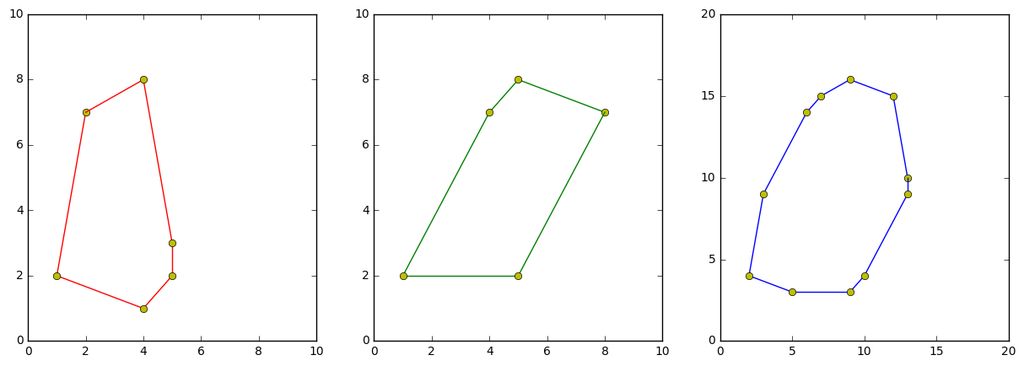

```python
# Тут реализована иллюстрация происходящего.

# Фигуры нарисованные на картинках.
# A = PointSet([Point(1, 4), Point(3, 4), Point(2, 6)])
# B = PointSet([Point(4, 1), Point(6, 2), Point(4, 3)])

# Случайно сгенерированные фигуры.
A = rand_figure()
B = rand_figure()

# Создаем область для картинок .
fig = plt.figure(figsize = (15, 5))

# Рисуем многоугольники A, B в первых 2х областях.
# paint_polygon(figure, place, polygon:PointSet, line_color, point_color, min_x/y, max_x/y)
paint_polygon(fig, 131, A, "r", "yo", 0, 10)
paint_polygon(fig, 132, B, "g", "yo", 0, 10)

# Считаем сумму Минковского A и B.
# example_alg(polygon1:PointSet, polygon2:PointSet)
C = example_alg(A, B)

# Рисуем многоугольник C в третьей области.
paint_polygon(fig, 133, C, "b", "yo", 0, 20)

plt.show()
```

## Сумма двух невыпуклых фигур

Чтобы найти сумму Минковского для двух невыпуклых фигур можно разбить каждую фигуру на выпуклые фигуры (например, треугольники), просуммировать их, а потом объединить получившиеся суммы.

#### Утверждение

> $(A \cup B) \oplus C \equiv (A \oplus C) \cup (B \oplus C)$

#### Утверждение

> Объединение $O(n)$ выпуклых фигур с $O(1)$ вершинами в худшем случаем может дать фигуру с $O(n^2)$ вершинами.

В случае суммы Минковского $n$ - угольника и $m$ - угольника, после разбиения у нас получится множество из $(n - 2)$ треугольника и из $(m - 2)$ треугольника. Сложив попарно все треугольники между собой, получим множество из $O(nm)$ фигур, с $O(1)$ вершин в каждой. После объединения в худшем случае получается фигура с $O((nm)^2)$ вершин. Эта оценка достижима (пример).

[figure not shown]

Замечание: при симметричном увеличении количества зубцов любой из фигур в 2 раза и их продлении, количество точек в сумме Минковского увеличится в 4 раза.